# 공공데이터를 활용한 지하철 역사 및 노선도 shapefile 제작

방준아

# 원자료 : 지하철 역사 및 노선 배경지도

현재 행정안전부에서 지하철 역사 및 노선도 배경지도가 공공데이터로 제공되고 있다. 하지만, 각 원자료는 일부 역 또는 노선이 제공되지 않는다는 오류가 있다. 또한, 두 배경지도가 분리되어 제공되기 때문에 사용이 제한적이다. 예를 들어, 지하철 역사 배경지도는 노선 정보가 제공되지 않기 때문에 노선별로 역의 위치를 관찰하는 것에 한계가 있다. 지하철 노선도 배경지도는 역 정보를 포함하고 있지 않기 때문에 노선에서 특정 역 위치에 대한 관찰이 어렵다. 따라서 이러한 원자료의 오류를 해결하고 역과 노선의 배경지도의 결합이 가능한 shapefile을 제작한다. 자세한 과정은 다음과 같다.

### 지하철 역사 배경지도

```
## Simple feature collection with 6 features and 4 fields
## geometry type:  MULTIPOLYGON
## dimension:      XY
## bbox:           xmin: 126.8426 ymin: 37.45451 xmax: 126.9027 ymax: 37.49517
## epsg (SRID):    4326
## proj4string:    +proj=longlat +datum=WGS84 +no_defs
##    SIG_CD     KOR_SUB_NM       OPERT_DE SUB_STA_SN
## 4   11530 구로디지털단지       20070807         60
## 9   11530           대림 20161124210909        146
## 11  11530         오류동 20161124210909        148
## 12  11545 가산디지털단지 20161124211933         54
## 14  11545       금천구청 20160912121034         56
## 15  11560 구로디지털단지       20101115        217
##                          geometry
## 4  MULTIPOLYGON (((126.9021 37...
## 9  MULTIPOLYGON (((126.8952 37...
## 11 MULTIPOLYGON (((126.8446 37...
## 12 MULTIPOLYGON (((126.8822 37...
## 14 MULTIPOLYGON (((126.8943 37...
## 15 MULTIPOLYGON (((126.9006 37...
```

### 지하철 노선 배경지도

```
## Simple feature collection with 6 features and 4 fields
## geometry type:  MULTILINESTRING
## dimension:      XY
## bbox:           xmin: 126.9007 ymin: 37.57609 xmax: 127.0843 ymax: 37.61993
## epsg (SRID):    4326
## proj4string:    +proj=longlat +datum=WGS84 +no_defs
##     SIG_CD KOR_SBR_NM       OPERT_DE SUB_RLW_SN
## 125  11350      6호선 20161124203744         20
## 126  11380      3호선 20161124204842          6
## 127  11380      6호선 20161124204842          7
## 128  11380      6호선 20161124204842          8
## 129  11380      6호선 20161124204842          9
## 130  11380      6호선 20161124204842         10
##                           geometry
## 125 MULTILINESTRING ((127.0843 ...
## 126 MULTILINESTRING ((126.9357 ...
## 127 MULTILINESTRING ((126.9007 ...
## 128 MULTILINESTRING ((126.9097 ...
## 129 MULTILINESTRING ((126.9137 ...
## 130 MULTILINESTRING ((126.916 3...
```

# 원자료의 문제

### 지하철 역사 배경지도

이 원자료의 경우 모든 역에 대한 정보를 포함하지 않는다는 오류가 존재한다. 가천대, 광운대, 지평, 개롱 등 10개 역에 대한 정보가 누락되어 있다. 또한, 잠실새내역과 같이 역명이 변경되었음에도 구역명인 신천역으로 표기된 경우가 있다. 따라서 수도권 내 469개의 역에 대한 정보를 포함하도록 수정이 필요하다.

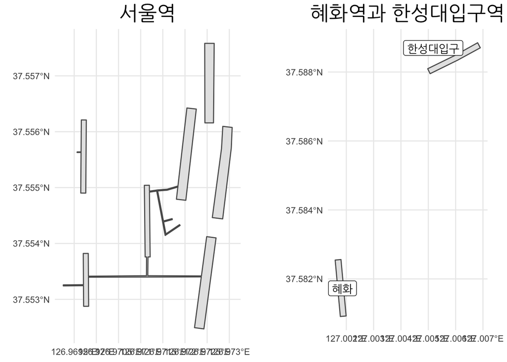

또한, 원자료는 위의 그림과 같이 역의 형태로 제공된다. 지하철 노선도 shapefile과의 결합과 효율적인 역의 위치 파악을 위해 지하철 역의 위치를 하나의 점의 형태로 제공하고자 한다. 점의 위치는 역을 이루는 출구들의 위경도 값에 대한 30% 절사평균값으로 한다. 이는 멀리 떨어져 있는 출구는 고려하지 않기 위함이다. 이와같은 과정을 통해 다음과 같은 지하철 노선도 shapefile을 얻는다.

## 지하철 노선도 배경지도

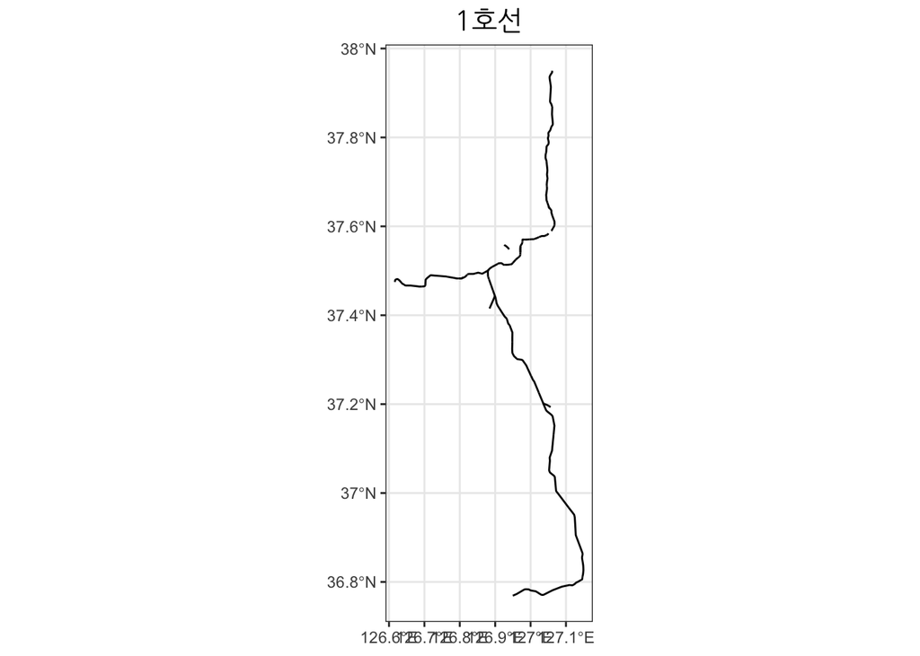

## 원자료의 오류를 해결한 배경지도

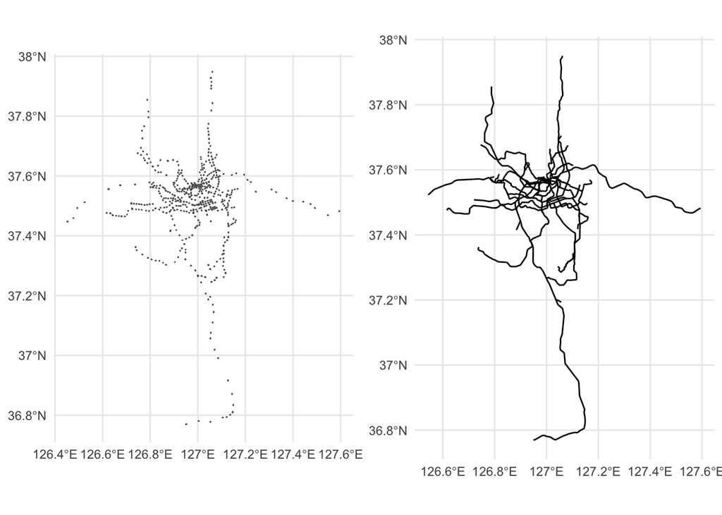

## 결과 (1호선 예시)

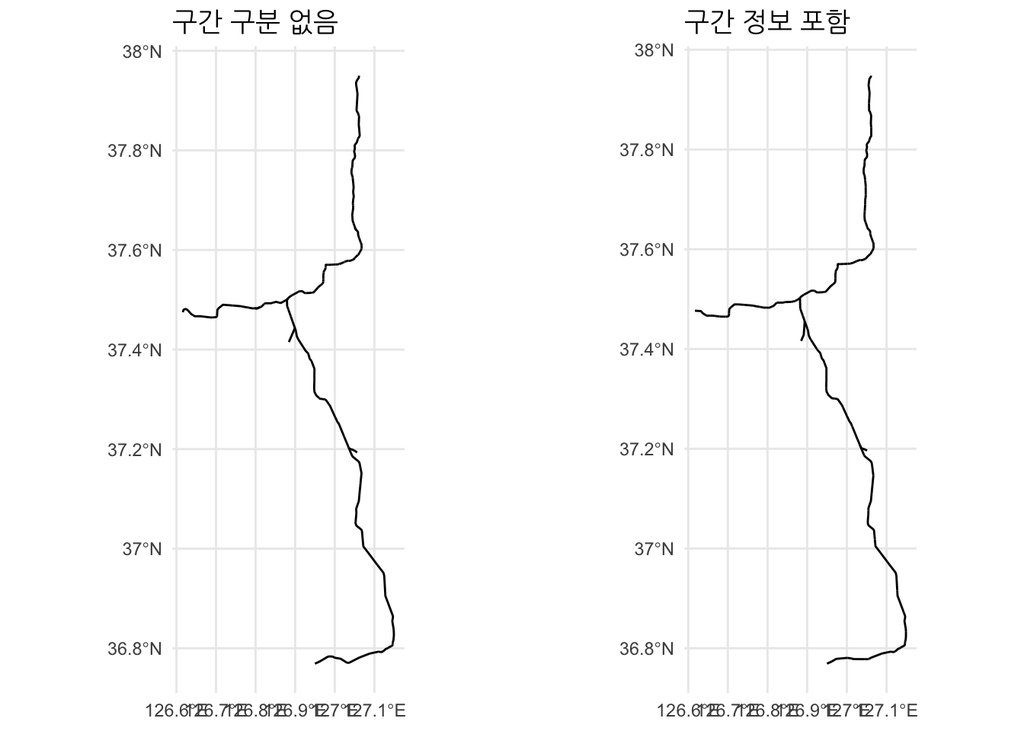

- 왼쪽의 기존 노선과 오른쪽의 구간 정보를 포함한 노선의 형태가 동일함 확인 가능
- `get_section_coor_sf(sub_line_choose, line_sf)`을 통해 노선에 역의 정보 및 구간의 정보를 부여함
- 오른쪽의 노선은 구간을 의미하는 선(LINESTRING)으로 구성됨

## `get_section_coor_sf(sub_line_choose, line_sf)`

- `sub_line_choose` : 노선(`seoulsubway` R 패키지의 노선과 동일)

  ```
      예) `1`, `1_P`, `1_A`, `1_B` 등
  ```

- `line_sf` : 노선에 대한 sf object

### 함수 내용(노선에 구간 정보를 부여하는 과정)

1. `sf` 패키지의 `st_nearest_feature(x, y)`를 이용하여 기존 지하철 노선의 sf object에 지하철 역과 가장 가까운 점을 찾아 역 정보 부여
2. 지하철 노선을 이루는 점 중 지하철 역과 가까운 점이 없다면 지하철 역인 점을 더하여 역 정보를 직접 부여
3. 구간 시작/끝점의 위경도정보를 기준으로 직사각형의 범위 내에 존재하는 점들을 하나의 구간으로 정의
   - 이 때, 직사각형 범위 내 점들을 위경도를 기준으로 나열
   - 하지만, 노선이 구불구불한 경우에는 위경도 기준으로 나열하지 않고 점들의 순서를 고려하여 재정렬
4. 1-3의 과정을 전체 노선 별로 반복

## 과정

- 1호선에 `get_section_coor_sf()` 적용

```r
line_1_output <- get_section_coor_sf('1', subwayline_sf) %>%
  rbind(get_section_coor_sf('1_A', subwayline_sf)) %>%
  rbind(get_section_coor_sf('1_B', subwayline_sf)) %>%
  rbind(get_section_coor_sf('1_P', subwayline_sf))
```

- `get_section_coor_sf()` 결과 예시

```r
line_1_output %>%
  filter(section=='소요산-동두천')
```

```
##          section     long      lat station line
## 1  소요산-동두천 127.0546 37.92850  동두천    1
## 2  소요산-동두천 127.0546 37.92850     non    1
## 3  소요산-동두천 127.0568 37.94154     non    1
## 4  소요산-동두천 127.0598 37.94487     non    1
## 5  소요산-동두천 127.0601 37.94523     non    1
## 6  소요산-동두천 127.0603 37.94562     non    1
## 7  소요산-동두천 127.0607 37.94640     non    1
## 8  소요산-동두천 127.0607 37.94670     non    1
## 9  소요산-동두천 127.0608 37.94713     non    1
## 10 소요산-동두천 127.0609 37.94794     non    1
## 11 소요산-동두천 127.0609 37.94794  소요산    1
```

- `section`(구간), `long`, `lat`(위경도 정보), `station`(역), `line`(호선) 으로 구성
- `station`의 경우 구간의 시작/끝점이 아닌 경우 `"non"`
- `section`을 기준으로 MULTILINESTRING 생성

```r
line_1_output %>%
  st_as_sf(coords = c("long", "lat"), crs = 4326) %>%
  group_by(section) %>%
  summarise(do_union = FALSE) %>%
  st_cast("MULTILINESTRING") %>% head
```

```
## Simple feature collection with 6 features and 1 field
## geometry type:  MULTILINESTRING
## dimension:      XY
## bbox:           xmin: 126.6793 ymin: 37.40058 xmax: 127.0657 ymax: 37.74881
## epsg (SRID):    4326
## proj4string:    +proj=longlat +datum=WGS84 +no_defs
## # A tibble: 6 x 2
##   section                                                          geometry
##   <chr>                                               <MULTILINESTRING [°]>
## 1 가능-의정부     ((127.0442 37.74881, 127.0442 37.74881, 127.0445 37.7480…
## 2 가산디지털단지-독산… ((126.8824 37.4811, 126.8824 37.4811, 126.8824 37.4811, …
## 3 간석-주안       ((126.6793 37.46515, 126.6793 37.46515, 126.6821 37.4648…
## 4 개봉-오류동     ((126.8437 37.49403, 126.8437 37.49403, 126.8437 37.4940…
## 5 관악-안양       ((126.9091 37.41885, 126.9091 37.41885, 126.9092 37.4186…
## 6 광운대-석계     ((127.0615 37.62381, 127.0615 37.62381, 127.0615 37.6238…
```

## 한계

- 구간 시작/끝점의 위경도 정보를 이용하여 직사각형 안의 점들을 하나의 구간으로 정의했기 때문에 직사각형 밖에 위치한 점들은 누락되는 경우가 있음

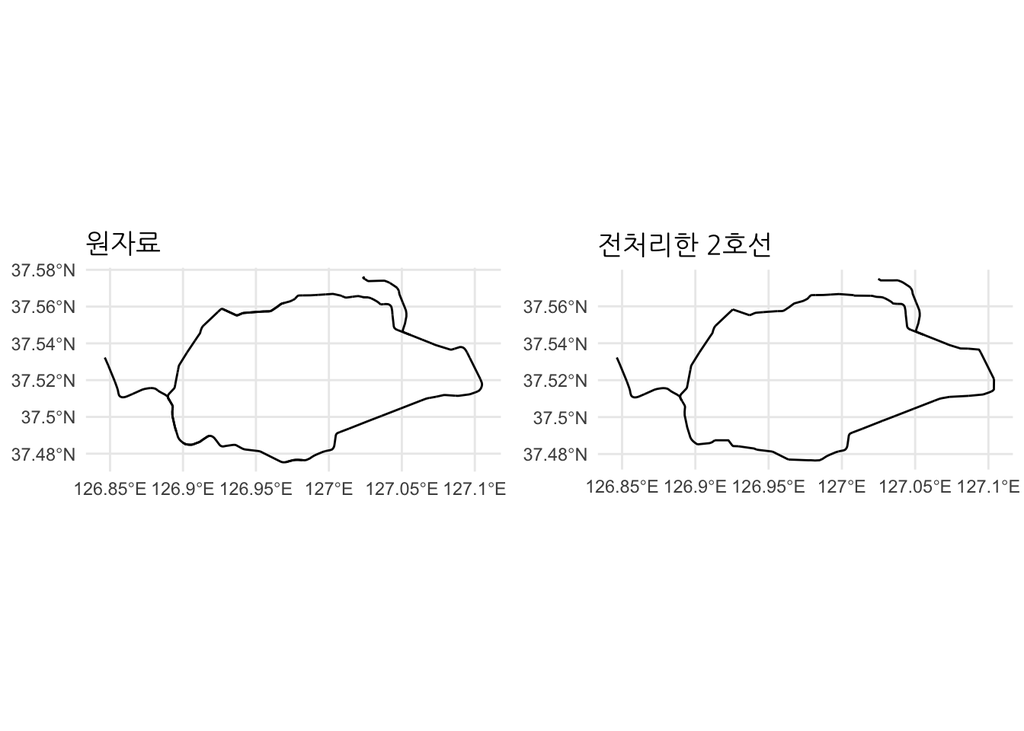

- 2호선을 예시로 비교하면, 크게 문제는 없어 보임

  ```
  - 오른쪽에 살짝 튀어나온 부분이 잘린 모습을 확인 가능
  ```

- 공항철도의 경우 원자료가 공항철도의 모든 부분을 포함하지 않음

  ```
  - 제공되지 않는 노선의 경우 역들을 직선으로 이어서 대체
  ```

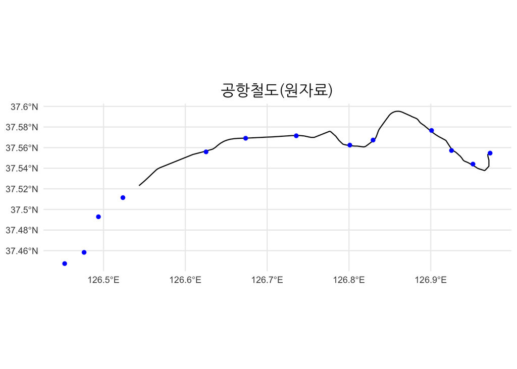